# Relación Minutos

## **Proyecto 1 - Relación Minutos Ingreso**

> > **Especialización en Machine Learning**

> > **Machine Learning**

> > **Universidad EAN 2024**

> > *Profesor: Sergio David Díaz*

> > **Integrantes de grupo:**
> > - Luis Fernando Cruz.
> > - Daniel Alejandro Rodríguez.
> > - Luisa Fernanda Tirado León.

# Descripción del problema:

> La base de datos Credito_dias.csv contiene información acerca del comportamiento de los clientes de una empresa de telecomunicaciones cuya información contiene: ingresos del cliente, total de minutos usados por el cliente, indicador de tarjeta de crédito y antigüedad del equipo actual. Con esta información, se propone identificar mediante el uso de herramientas de Machine Learning si es posible afirmar que cuando una persona tiene un mayor ingreso entonces, es mayor la el uso de minutos o la relación entre ingreso y minutos es inversa.

## 1. ANÁLISIS DESCRIPTIVO DEL DATASET

```python
# Librerías necesarias
import pandas as pd
import matplotlib.pyplot as plt
import seaborn as sns
```

```python
# Cargue de la información del dataset
data = pd.read_csv('Credito_dias.csv')
print("Primeras filas del dataset:")
print(data.head())
```

```
Primeras filas del dataset:
    totmou   totrev creditcd  eqpdays  Customer_ID
0   7269.0   906.58        Y      371      1082423
1  13552.0  1172.25        N       83      1069232
2   4152.0   577.39        Y      675      1031705
3   1863.0   294.26        Y      218      1089806
4   4155.0   433.16        N      222      1076695
```

```python
print("Descripción estadística del dataset:")
print(data.describe())
```

```
Descripción estadística del dataset:
              totmou        totrev       eqpdays   Customer_ID
count   10000.000000  10000.000000  10000.000000  1.000000e+04
mean     7692.804866   1042.133807    386.794500  1.049965e+06
std      8657.917883    857.144895    252.720196  2.879424e+04
min         0.000000     11.100000     -5.000000  1.000014e+06
25%      2576.000000    526.787500    210.000000  1.025053e+06
50%      5262.000000    820.235000    338.000000  1.049652e+06
75%      9823.250000   1272.975000    522.000000  1.074798e+06
max    163264.176700  13426.600000   1823.000000  1.099992e+06
```

```python
print("Información general del dataset:")
print(data.info())
```

```
Información general del dataset:
<class 'pandas.core.frame.DataFrame'>
RangeIndex: 10000 entries, 0 to 9999
Data columns (total 5 columns):
 #   Column       Non-Null Count  Dtype
---  ------       --------------  -----
 0   totmou       10000 non-null  float64
 1   totrev       10000 non-null  float64
 2   creditcd     9848 non-null   object
 3   eqpdays      10000 non-null  int64
 4   Customer_ID  10000 non-null  int64
dtypes: float64(2), int64(2), object(1)
memory usage: 390.8+ KB
None
```

Se evidencia la presencia de valores nulos

```python
# Total de valores nulos por columna
print("Cantidad de valores nulos por columna:")
print(data.isnull().sum())
```

```
Cantidad de valores nulos por columna:
totmou           0
totrev           0
creditcd       152
eqpdays          0
Customer_ID      0
dtype: int64
```

Se observan 152 datos nulos dentro del dataset, si bien representan el 1,5% de la información de creditcd, al desconocer el valor de estos resultados y su posible impacto en el análisis, se procece a crear una categoría nueva con ellos llamada "Desconocido".

```python
# Nueva categoría'Desconocido'.
data['creditcd'].fillna('Desconocido', inplace=True)
```

```python
# Validad reemplazo de valores nulos
data['creditcd'].value_counts()
```

```
Y              6796
N              3052
Desconocido     152
Name: creditcd, dtype: int64
```

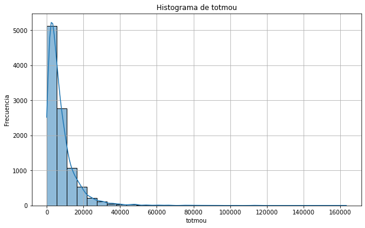

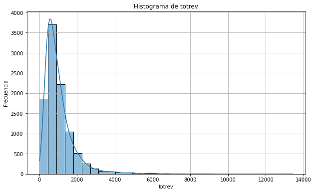

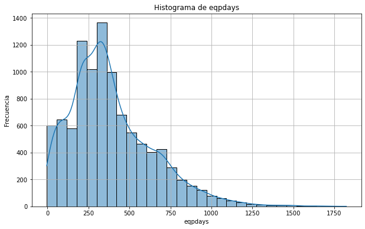

```python
# Análisis de variables numéricas
numerical_vars = ['totmou', 'totrev', 'eqpdays']
for var in numerical_vars:
    plt.figure(figsize=(10, 6))
    sns.histplot(data[var], kde=True, bins=30)
    plt.title(f'Histograma de {var}')
    plt.xlabel(var)
    plt.ylabel('Frecuencia')
    plt.grid(True)
    plt.show()
```

**Histogramas de Variables Numéricas**: Los datos revelan que la mayoría de los clientes tienden a utilizar menos minutos y, de manera similar, la mayor concentración de clientes se observa en los rangos inferiores de ingresos generados. Asimismo, es notable que una gran proporción de clientes ha adquirido sus equipos en un período relativamente corto, lo que sugiere un reciente incremento en la adquisición de nuevos equipos.

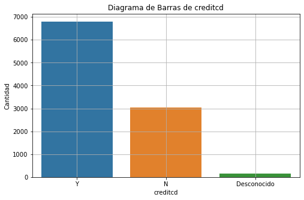

```python
# Diagramas de barras para variables categóricas
categorical_vars = ['creditcd']
for var in categorical_vars:
    plt.figure(figsize=(8, 5))
    sns.countplot(x=var, data=data)
    plt.title(f'Diagrama de Barras de {var}')
    plt.xlabel(var)
    plt.ylabel('Cantidad')
    plt.grid(True)
    plt.show()
```

**Histogramas de Variables Categóricas**: Más del 60% de los clientes cuentan con tarjeta de crédito mientras que apróximadamente el 30% de los clientes no cuentan con tarjeta de crédito representando la mitad de los clientes con tarjeta de crédito. Un porcentaje mínimo tienen un estado "Desconocido" ( se desconoce si tienen o no tarjeta de crédito)

## 1. ANÁLISIS DE CORRELACIÓN

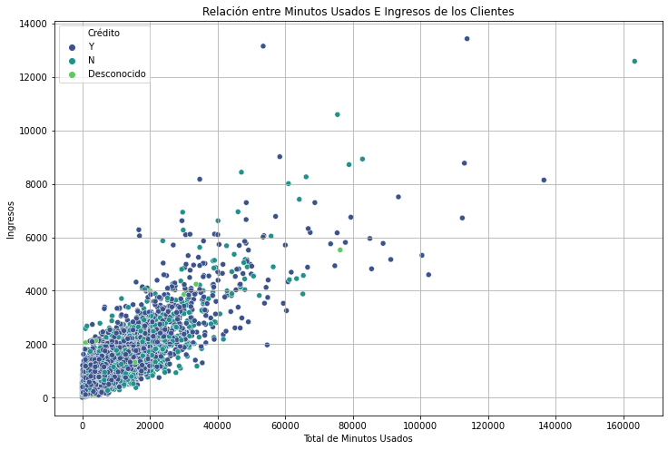

```python
## Diagrama de dispersión entre totmou y totrev
plt.figure(figsize=(12, 8))
sns.scatterplot(x='totmou', y='totrev', hue='creditcd', data=data, palette='viridis')
plt.title('Relación entre Minutos Usados E Ingresos de los Clientes')
plt.xlabel('Total de Minutos Usados')
plt.ylabel('Ingresos')
plt.legend(title='Crédito')
plt.grid(True)
plt.show()
```

```python
# Calcular la correlación
correlation = data[['totmou', 'totrev']].corr()
print("Coeficiente de correlación entre minutos usados e ingresos:")
print(correlation)
```

```
Coeficiente de correlación entre minutos usados e ingresos:
          totmou    totrev
totmou  1.000000  0.835485
totrev  0.835485  1.000000
```

**Análisis de correlación:** A partir de esta información se puede responder a la pregunta problema de este informe ya que se puede evidenciar que **existe una relación positiva fuerte entre el total de minutos usados (totmuo) y los ingresos por cliente(totrev)** es decir, a medida que los minutos usados aumentan, también aumentan los ingresos; no obstante, la mayoría de los datos se agrupan en la parte inferior izquierda lo que implica que la mayoría de los clientes usan menos minutos y generan por tanto menos ingreso: Además, con respecto al uso de tarjetas de crédito, se puede inferir que los clientes con tarjeta de crédito presentan una mayor dispersión en cuanto al uso de minutos e ingresos generados.